# Public Interest Data

2024-03-11

## Pivot: Longer

`pivot_longer`: Convert wide data to long, or move variable values out of the column names and into the cells.

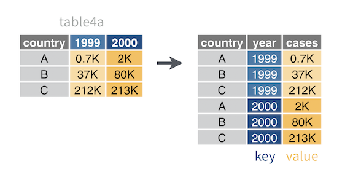

`pivot_longer(df, cols = -country, names_to = "year", values_to = "cases")`

## Pivot: Wider

`pivot_wider`: Convert long data to wide, or move variable names out of the cells and into the column names.

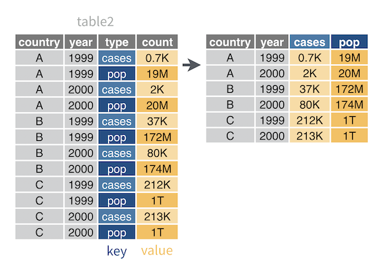

`pivot_wider(df, id_cols = country, names_from = type, values_from = count)`

## Themes

Themes allow you to control the non-data elements of your plot – the appearance of titles, legends, backgrounds, etc.

- ggplot2 has additional built-in themes
- Additional packages have pre-built themes (e.g., ggthemes)

For more detail on themes

- https://ggplot2.tidyverse.org/reference/theme.html – to see all of the possible arguments
- https://ggplot2-book.org/themes – to learn all about making theming changes

## Annotation

Adding text:

- `geom_text()`: for labeling plots, like points on a scatterplot or the height of bars
- `ggtext` package: supports markdown and html elements in ggplot (e.g., we can add colors to text elements)
- `annotate()`: for adding small text annotations at a particular location on the plot

`annotate()` can also be used to add elements besides text, e.g., arrows, lines, shading.

## Let’s Play with R!

Download R script from today’s canvas page!

[figure not shown]

Artwork by @allison_horst